# CIA-2

venkata sai krishna Nivarthi

12/08/2021

#Problem statement-An automobile industry which manufactures and sells vehicles, after few years, the company seemes that many of the customers are not extending their insurance.The purpose of this project is to determine the response of the customer whether they would accept or reject the offer we make based on the customer profile. The profile of the customer is built upon based on details such as Employment status, Marital status, Income group, etc.The aim of this analysis to get know whether our insurance customers will extend their vehicle insurance based on their behaviour or not.

#Objectives #1. To get to know whether our insurance customers will extend their vehicle insurance based on their behaviour #2. To know which independent variables show relationship among the response variable (dependent variable). #3. To know how much the independent variable contributing to the response variable(dependent variable) #4. To know whether the model is good to implement or not. #5. To find which variables are significant with respect to dependent variable with regards to step-AIC function.

#Importing the dataset and storing it as data1 and viewing the dataset

```r
data1<-read.csv("C:\\Users\\LOKSAI\\Downloads\\Customer_Purchase-Marketing-Analysis.csv", stringsAsFactor= TRUE)

head(data1)
```

```
##   Customer      State Customer.Lifetime.Value Response Coverage Education
## 1  BU79786 Washington                2763.519       No    Basic  Bachelor
## 2  QZ44356    Arizona                6979.536       No Extended  Bachelor
## 3  AI49188     Nevada               12887.432       No  Premium  Bachelor
## 4  WW63253 California                7645.862       No    Basic  Bachelor
## 5  HB64268 Washington                2813.693       No    Basic  Bachelor
## 6  OC83172     Oregon                8256.298      Yes    Basic  Bachelor
##   Effective.To.Date EmploymentStatus Gender Income Location.Code Marital.Status
## 1           2/24/11         Employed      F  56274      Suburban        Married
## 2           1/31/11       Unemployed      F      0      Suburban         Single
## 3           2/19/11         Employed      F  48767      Suburban        Married
## 4           1/20/11       Unemployed      M      0      Suburban        Married
## 5            2/3/11         Employed      M  43836         Rural         Single
## 6           1/25/11         Employed      F  62902         Rural        Married
##   Monthly.Premium.Auto Months.Since.Last.Claim Months.Since.Policy.Inception
```

[output cut: 20 more lines]

#Customer id and Effective To Date is not important for performing this logistic regression, so I will drop them. The data is inbalanced regarding the outcome so dropping it.

```r
data1 = subset(data1, select = -c(Customer,Effective.To.Date))
str(data1)
```

```
## 'data.frame':    9134 obs. of  22 variables:
##  $ State                        : Factor w/ 5 levels "Arizona","California",..: 5 1 3 2 5 4 4 1 4 4 ...
##  $ Customer.Lifetime.Value      : num  2764 6980 12887 7646 2814 ...
##  $ Response                     : Factor w/ 2 levels "No","Yes": 1 1 1 1 1 2 2 1 2 1 ...
##  $ Coverage                     : Factor w/ 3 levels "Basic","Extended",..: 1 2 3 1 1 1 1 3 1 2 ...
##  $ Education                    : Factor w/ 5 levels "Bachelor","College",..: 1 1 1 1 1 1 2 5 1 2 ...
##  $ EmploymentStatus             : Factor w/ 5 levels "Disabled","Employed",..: 2 5 2 5 2 2 2 5 3 2 ...
##  $ Gender                       : Factor w/ 2 levels "F","M": 1 1 1 2 2 1 1 2 2 1 ...
##  $ Income                       : int  56274 0 48767 0 43836 62902 55350 0 14072 28812 ...
##  $ Location.Code                : Factor w/ 3 levels "Rural","Suburban",..: 2 2 2 2 1 1 2 3 2 3 ...
##  $ Marital.Status               : Factor w/ 3 levels "Divorced","Married",..: 2 3 2 2 3 2 2 3 1 2 ...
##  $ Monthly.Premium.Auto         : int  69 94 108 106 73 69 67 101 71 93 ...
##  $ Months.Since.Last.Claim      : int  32 13 18 18 12 14 0 0 13 17 ...
##  $ Months.Since.Policy.Inception: int  5 42 38 65 44 94 13 68 3 7 ...
##  $ Number.of.Open.Complaints    : int  0 0 0 0 0 0 0 0 0 0 ...
##  $ Number.of.Policies           : int  1 8 2 7 1 2 9 4 2 8 ...
##  $ Policy.Type                  : Factor w/ 3 levels "Corporate Auto",..: 1 2 2 1 2 2 1 1 1 3 ...
##  $ Policy                       : Factor w/ 9 levels "Corporate L1",..: 3 6 6 2 4 6 3 3 3 8 ...
##  $ Renew.Offer.Type             : Factor w/ 4 levels "Offer1","Offer2",..: 1 3 1 1 1 2 1 1 1 2 ...
##  $ Sales.Channel                : Factor w/ 4 levels "Agent","Branch",..: 1 1 1 3 1 4 1 1 1 2 ...
##  $ Total.Claim.Amount           : num  385 1131 566 530 138 ...
##  $ Vehicle.Class                : Factor w/ 6 levels "Four-Door Car",..: 6 1 6 5 1 6 1 1 1 1 ...
##  $ Vehicle.Size                 : Factor w/ 3 levels "Large","Medsize",..: 2 2 2 2 2 2 2 2 2 2 ...
```

#Data Exploration

```r
sapply(data1, class)
```

```
##                         State       Customer.Lifetime.Value
##                      "factor"                     "numeric"
##                      Response                      Coverage
##                      "factor"                      "factor"
##                     Education              EmploymentStatus
##                      "factor"                      "factor"
##                        Gender                        Income
##                      "factor"                     "integer"
##                 Location.Code                Marital.Status
##                      "factor"                      "factor"
##          Monthly.Premium.Auto       Months.Since.Last.Claim
##                     "integer"                     "integer"
## Months.Since.Policy.Inception     Number.of.Open.Complaints
##                     "integer"                     "integer"
##            Number.of.Policies                   Policy.Type
##                     "integer"                      "factor"
##                        Policy              Renew.Offer.Type
##                      "factor"                      "factor"
##                 Sales.Channel            Total.Claim.Amount
##                      "factor"                     "numeric"
##                 Vehicle.Class                  Vehicle.Size
##                      "factor"                      "factor"
```

#Understanding the dataset with the structure and dimensions

```r
library(dplyr)
summary(data1)
```

```
##         State      Customer.Lifetime.Value Response       Coverage
##  Arizona   :1703   Min.   : 1898           No :7826   Basic   :5568
##  California:3150   1st Qu.: 3994           Yes:1308   Extended:2742
##  Nevada    : 882   Median : 5780                      Premium : 824
##  Oregon    :2601   Mean   : 8005
##  Washington: 798   3rd Qu.: 8962
##                    Max.   :83325
##
##                 Education         EmploymentStatus Gender       Income
##  Bachelor            :2748   Disabled     : 405    F:4658   Min.   :    0
##  College             :2681   Employed     :5698    M:4476   1st Qu.:    0
##  Doctor              : 342   Medical Leave: 432             Median :33890
##  High School or Below:2622   Retired      : 282             Mean   :37657
##  Master              : 741   Unemployed   :2317             3rd Qu.:62320
##                                                             Max.   :99981
##
##   Location.Code   Marital.Status Monthly.Premium.Auto Months.Since.Last.Claim
##  Rural   :1773   Divorced:1369   Min.   : 61.00       Min.   : 0.0
##  Suburban:5779   Married :5298   1st Qu.: 68.00       1st Qu.: 6.0
##  Urban   :1582   Single  :2467   Median : 83.00       Median :14.0
##                                  Mean   : 93.22       Mean   :15.1
##                                  3rd Qu.:109.00       3rd Qu.:23.0
##                                  Max.   :298.00       Max.   :35.0
##
##  Months.Since.Policy.Inception Number.of.Open.Complaints Number.of.Policies
##  Min.   : 0.00                 Min.   :0.0000            Min.   :1.000
##  1st Qu.:24.00                 1st Qu.:0.0000            1st Qu.:1.000
##  Median :48.00                 Median :0.0000            Median :2.000
##  Mean   :48.06                 Mean   :0.3844            Mean   :2.966
##  3rd Qu.:71.00                 3rd Qu.:0.0000            3rd Qu.:4.000
##  Max.   :99.00                 Max.   :5.0000            Max.   :9.000
##
##          Policy.Type            Policy     Renew.Offer.Type     Sales.Channel
##  Corporate Auto:1968   Personal L3 :3426   Offer1:3752      Agent      :3477
##  Personal Auto :6788   Personal L2 :2122   Offer2:2926      Branch     :2567
##  Special Auto  : 378   Personal L1 :1240   Offer3:1432      Call Center:1765
##                        Corporate L3:1014   Offer4:1024      Web        :1325
##                        Corporate L2: 595
##                        Corporate L1: 359
##                        (Other)     : 378
##  Total.Claim.Amount       Vehicle.Class   Vehicle.Size
##  Min.   :   0.099   Four-Door Car:4621   Large  : 946
##  1st Qu.: 272.258   Luxury Car   : 163   Medsize:6424
##  Median : 383.945   Luxury SUV   : 184   Small  :1764
##  Mean   : 434.089   Sports Car   : 484
##  3rd Qu.: 547.515   SUV          :1796
##  Max.   :2893.240   Two-Door Car :1886
##
```

```r
glimpse(data1)
```

```
## Rows: 9,134
## Columns: 22
## $ State                         <fct> Washington, Arizona, Nevada, California,~
## $ Customer.Lifetime.Value       <dbl> 2763.519, 6979.536, 12887.432, 7645.862,~
## $ Response                      <fct> No, No, No, No, No, Yes, Yes, No, Yes, N~
## $ Coverage                      <fct> Basic, Extended, Premium, Basic, Basic, ~
## $ Education                     <fct> Bachelor, Bachelor, Bachelor, Bachelor, ~
## $ EmploymentStatus              <fct> Employed, Unemployed, Employed, Unemploy~
## $ Gender                        <fct> F, F, F, M, M, F, F, M, M, F, M, F, M, M~
## $ Income                        <int> 56274, 0, 48767, 0, 43836, 62902, 55350,~
## $ Location.Code                 <fct> Suburban, Suburban, Suburban, Suburban, ~
## $ Marital.Status                <fct> Married, Single, Married, Married, Singl~
## $ Monthly.Premium.Auto          <int> 69, 94, 108, 106, 73, 69, 67, 101, 71, 9~
## $ Months.Since.Last.Claim       <int> 32, 13, 18, 18, 12, 14, 0, 0, 13, 17, 23~
## $ Months.Since.Policy.Inception <int> 5, 42, 38, 65, 44, 94, 13, 68, 3, 7, 5, ~
## $ Number.of.Open.Complaints     <int> 0, 0, 0, 0, 0, 0, 0, 0, 0, 0, 0, 0, 2, 1~
## $ Number.of.Policies            <int> 1, 8, 2, 7, 1, 2, 9, 4, 2, 8, 3, 3, 3, 8~
## $ Policy.Type                   <fct> Corporate Auto, Personal Auto, Personal ~
## $ Policy                        <fct> Corporate L3, Personal L3, Personal L3, ~
## $ Renew.Offer.Type              <fct> Offer1, Offer3, Offer1, Offer1, Offer1, ~
## $ Sales.Channel                 <fct> Agent, Agent, Agent, Call Center, Agent,~
## $ Total.Claim.Amount            <dbl> 384.81115, 1131.46493, 566.47225, 529.88~
## $ Vehicle.Class                 <fct> Two-Door Car, Four-Door Car, Two-Door Ca~
## $ Vehicle.Size                  <fct> Medsize, Medsize, Medsize, Medsize, Meds~
```

#sapply() function to count the number of observations with each feature that contains. #Checking the null values of each variable

```r
sapply(data1, function(x) sum(is.na(x)))
```

```
##                         State       Customer.Lifetime.Value
##                             0                             0
##                      Response                      Coverage
##                             0                             0
##                     Education              EmploymentStatus
##                             0                             0
##                        Gender                        Income
##                             0                             0
##                 Location.Code                Marital.Status
##                             0                             0
##          Monthly.Premium.Auto       Months.Since.Last.Claim
##                             0                             0
## Months.Since.Policy.Inception     Number.of.Open.Complaints
##                             0                             0
##            Number.of.Policies                   Policy.Type
##                             0                             0
##                        Policy              Renew.Offer.Type
##                             0                             0
##                 Sales.Channel            Total.Claim.Amount
##                             0                             0
##                 Vehicle.Class                  Vehicle.Size
##                             0                             0
```

#There are no null values with regards with each variable

#Similarly, the number of unique observations per column is revealed below. #This gives length of unique observations for each column variable

```r
sapply(data1, function(x) length(unique(x)))
```

```
##                         State       Customer.Lifetime.Value
##                             5                          8041
##                      Response                      Coverage
##                             2                             3
##                     Education              EmploymentStatus
##                             5                             5
##                        Gender                        Income
##                             2                          5694
##                 Location.Code                Marital.Status
##                             3                             3
##          Monthly.Premium.Auto       Months.Since.Last.Claim
##                           202                            36
## Months.Since.Policy.Inception     Number.of.Open.Complaints
##                           100                             6
##            Number.of.Policies                   Policy.Type
##                             9                             3
##                        Policy              Renew.Offer.Type
##                             9                             4
##                 Sales.Channel            Total.Claim.Amount
##                             4                          5106
##                 Vehicle.Class                  Vehicle.Size
##                             6                             3
```

#Using the missmap() function under the Amelia package, the visualization of the amount of missing and observed values per features is observed below. #This shows the missing and observed values in the form of visualization

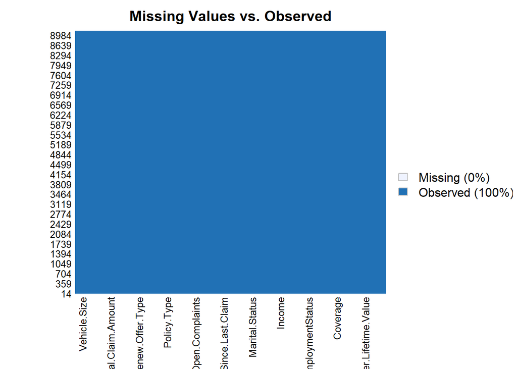

```r
library(Amelia)
missmap(data1, main = "Missing Values vs. Observed")
```

#There are no null values

#Each customer owns a car and you as entrepreneur offers 4 different car insurances to them. The target of this dataset is the Response.The response can be “Yes” - the customer accept the offer and “No” - the customer didn?t accept the offer. #Using Graphs to understand our Data # Relation between numerical variables

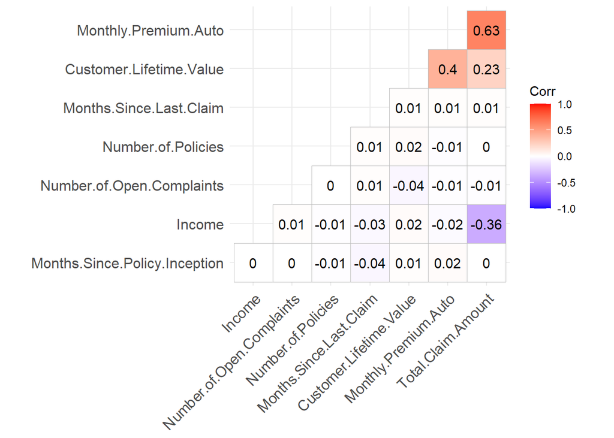

```r
nums = unlist(lapply(data1, is.numeric))
insurance_numeric=data1[,nums]
corr=cor(insurance_numeric)

library(ggcorrplot)
ggcorrplot(corr, hc.order = TRUE, type = "lower",lab = TRUE)
```

#1) this shows the correlation between the variables, this is done to understand about the varaibles relationship #2) the red colour indicates positive correlation, if one variable incrases, the other variable increases and vice versa, so if we increase total claim amount, the monthly premium will increase. #3) The blue colour iindicates that there is negative correlation, if ne variables increases, the other decreases and vice versa. In this case, income increase, the total claim amount decreases or vice versa. #4) the white colour represents there is no corrleation between the variables.

## Exploratory Data Analysis

##Relation between categorial variables and response variable Gender - > Response

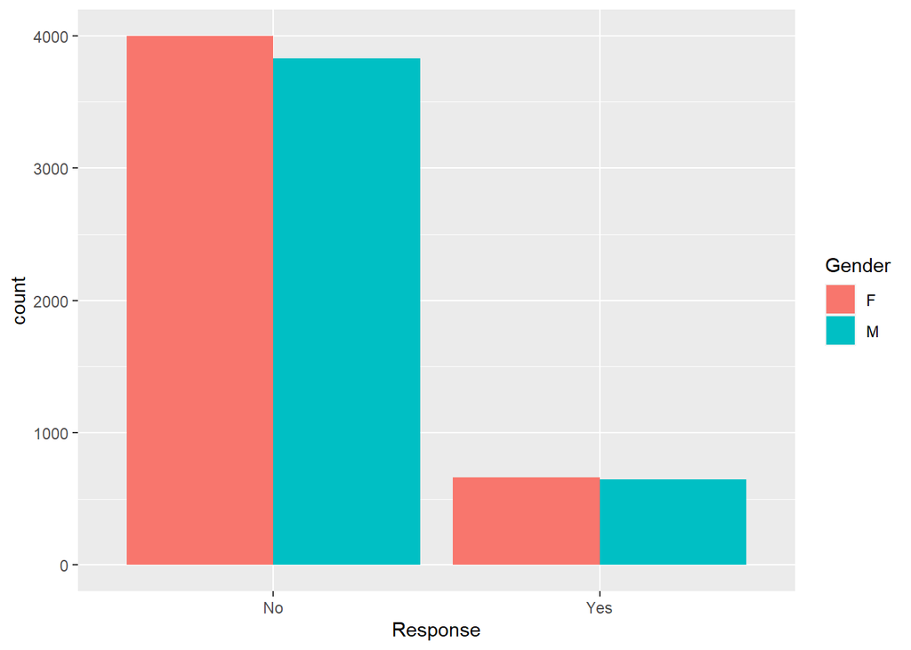

```r
library(ggplot2)

ggplot(data1, aes(Response, fill= Gender))+geom_bar(position='dodge')
```

##Relationship between Response and State

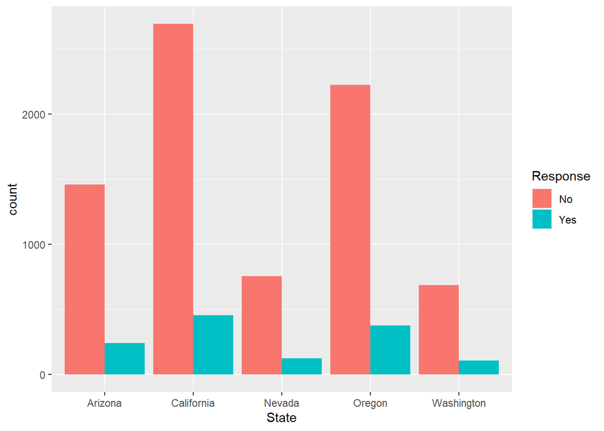

```r
ggplot(data1, aes(State, fill= Response))+geom_bar(position='dodge')
```

#The no responses are more from california when compared to all states, its nearly 3000. An the least no are from washington. #The Yes response are also more from california, this means there are more population from california

##Relationship between Response and Coverage

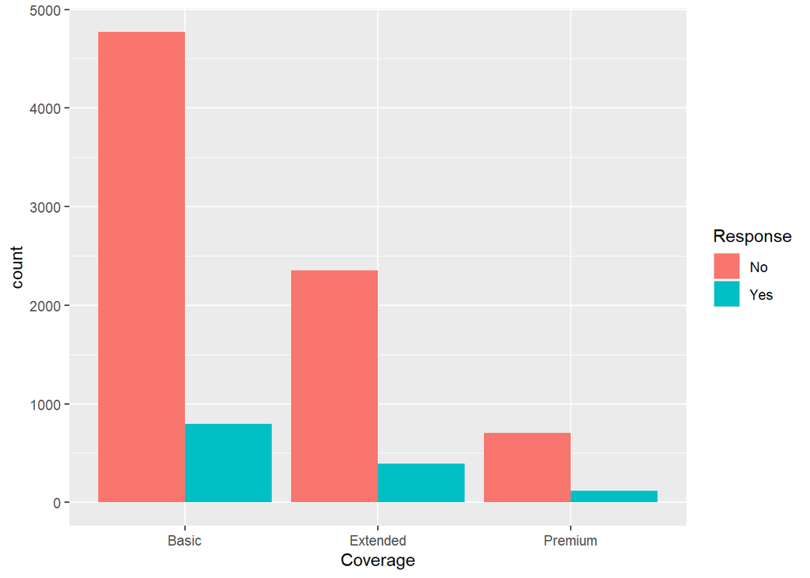

```r
ggplot(data1, aes(Coverage, fill= Response))+geom_bar(position='dodge')
```

#Basic coverage people are not intrested in extending their insurance compared to extended and premium. #the highest to lowest range follows in this order- basic, extended, premium.

###Relationship between Response and Education

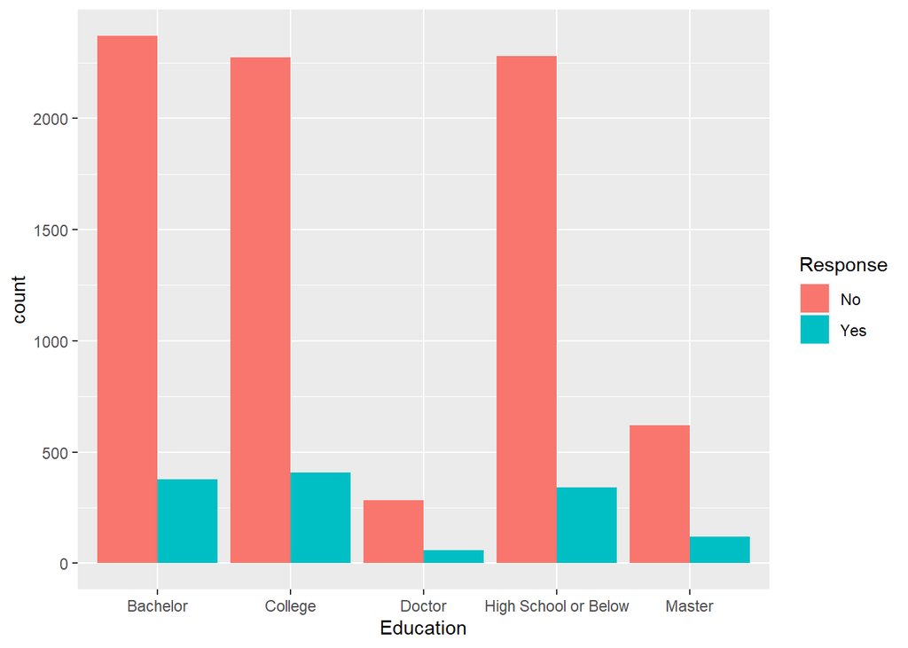

```r
ggplot(data1, aes(Education, fill= Response))+geom_bar(position='dodge')
```

#College going and bachelor are intrested in extending the insurance premium and also they are the most who has responded no for this data.

##Relationship between Response and Location code

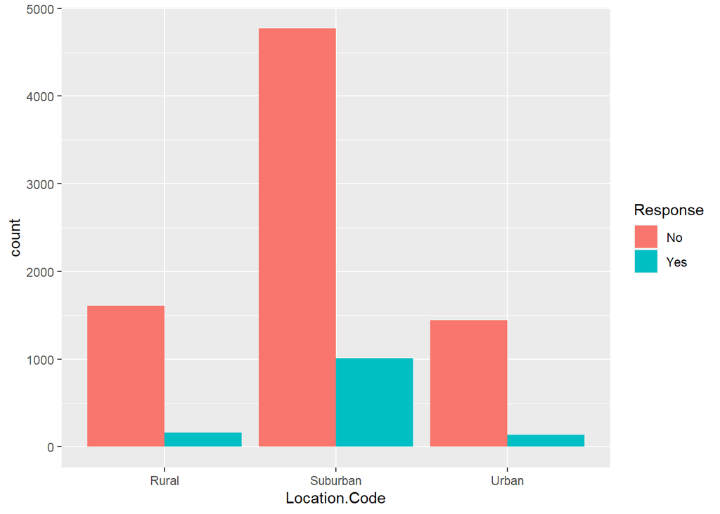

```r
ggplot(data1, aes(Location.Code, fill= Response))+geom_bar(position='dodge')
```

#The sururban people are not intrested in extension of the insurance and they have the more votes. #the urban and rural are very less, who agreed to extend.

##Relationship between Response and marital status

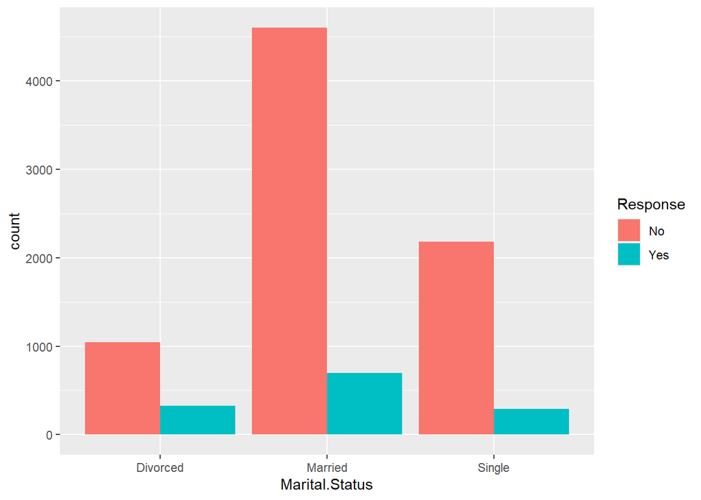

```r
ggplot(data1, aes(Marital.Status, fill= Response))+geom_bar(position='dodge')
```

#Married people are more intrestd in extending the insurance when compared to divorced and single.

##Relationship between Response and Months since last claim

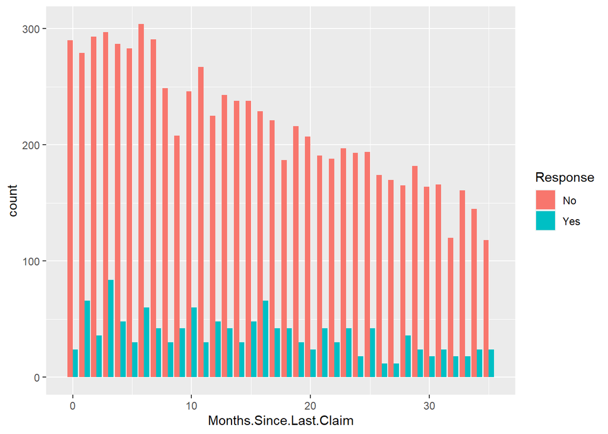

```r
ggplot(data1, aes(Months.Since.Last.Claim, fill= Response))+geom_bar(position='dodge')
```

#The responses for months since last claim are no are more when compared to yes.

##Relationship between Response and Number.of.Open.Complaints

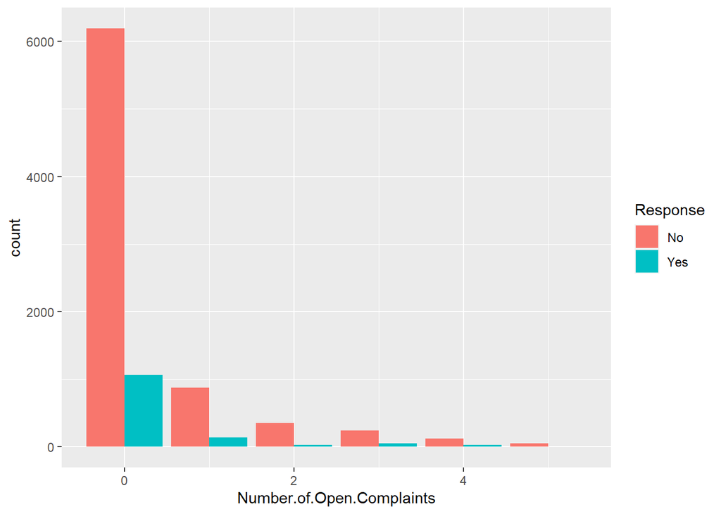

```r
ggplot(data1, aes(Number.of.Open.Complaints, fill= Response))+geom_bar(position='dodge')
```

#No complaited people are inttrested in extending their insurance premium.

##Relationship between Response and No of policies

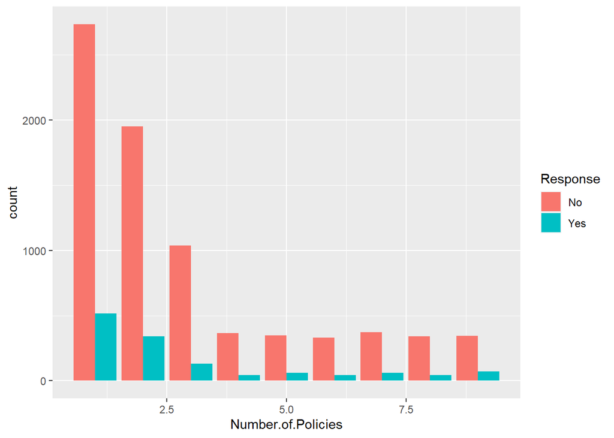

```r
ggplot(data1, aes(Number.of.Policies, fill= Response))+geom_bar(position='dodge')
```

##Relationship between Response and Policy type

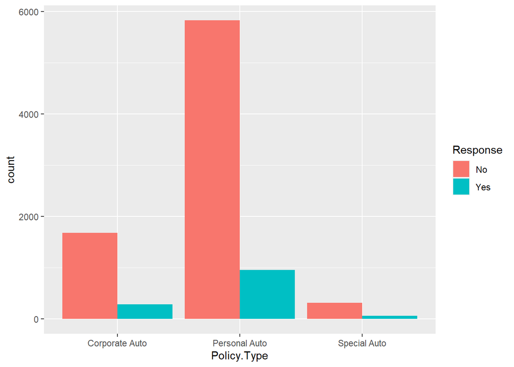

```r
ggplot(data1, aes(Policy.Type, fill= Response))+geom_bar(position='dodge')
```

#Personal auto type of people have responded yes to extend their plan for the insurance premium when compared to corporate auto and special auto.

##Relationship between Response and renew offer type

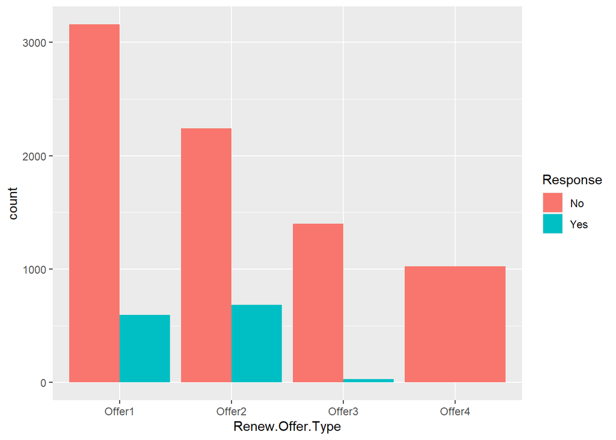

```r
ggplot(data1, aes(Renew.Offer.Type, fill= Response))+geom_bar(position='dodge')
```

#Offer 4 people are not at all intrested in extending the insurance premium. #Offer 2 people are intrested most to extend their insurance premium and then offer 1 people.

##Relationship between Response and sales channel

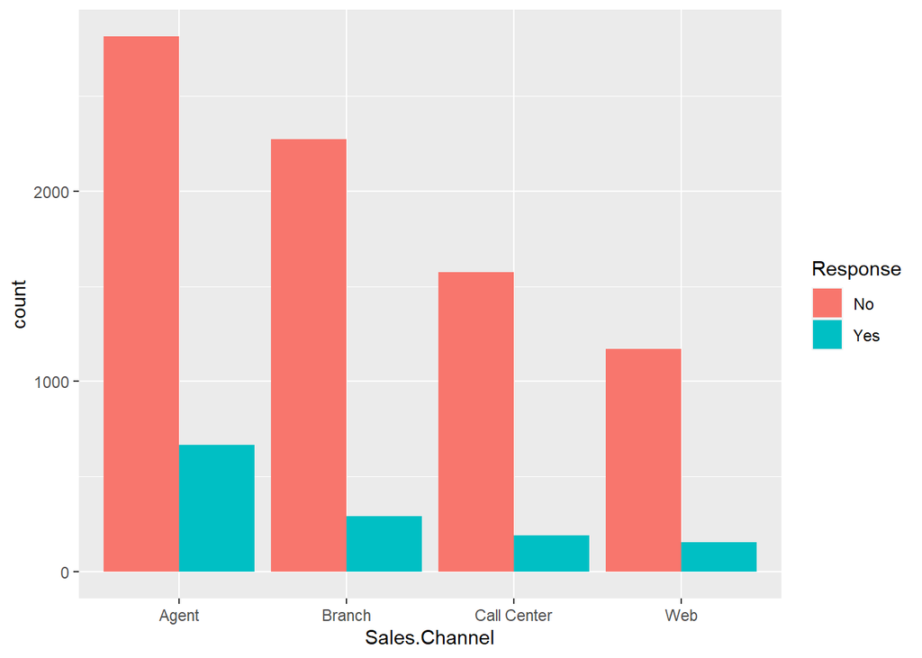

```r
ggplot(data1, aes(Sales.Channel, fill= Response))+geom_bar(position='dodge')
```

#The people who approached through agent are intrested in extending their insurance premium, this says that, agents are working more and grabbing more customers. #The order of extending the isurance premium is agaent, branch, call center, web of sales channel.

##Relationship between Response and vehicle class

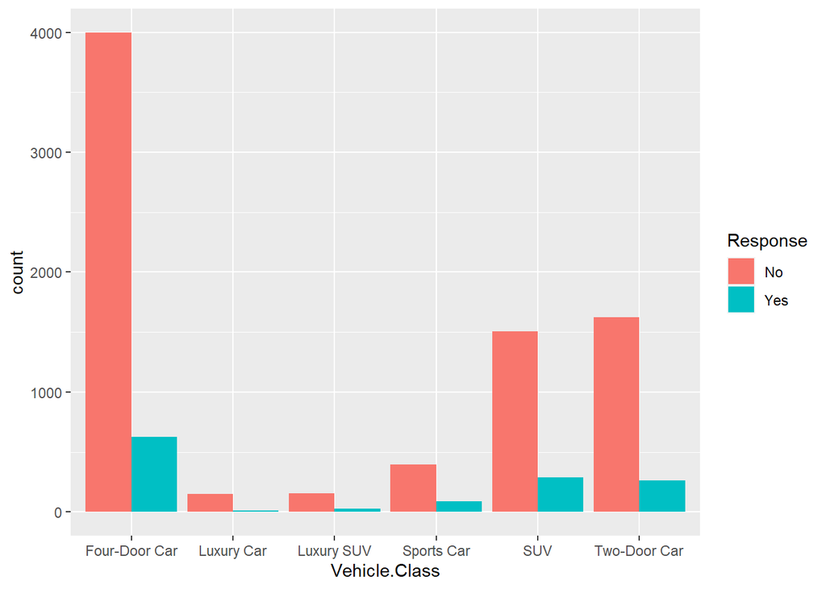

```r
ggplot(data1, aes(Vehicle.Class, fill= Response))+geom_bar(position='dodge')
```

#Four door car, two door car, suv car holders are intrested in extending their insurance premium, this says people with big cars are intrested in extedning their insuranc epremium. #Luxury car and luxury suv are least interested.

##Relationship between Response and Vehicle size

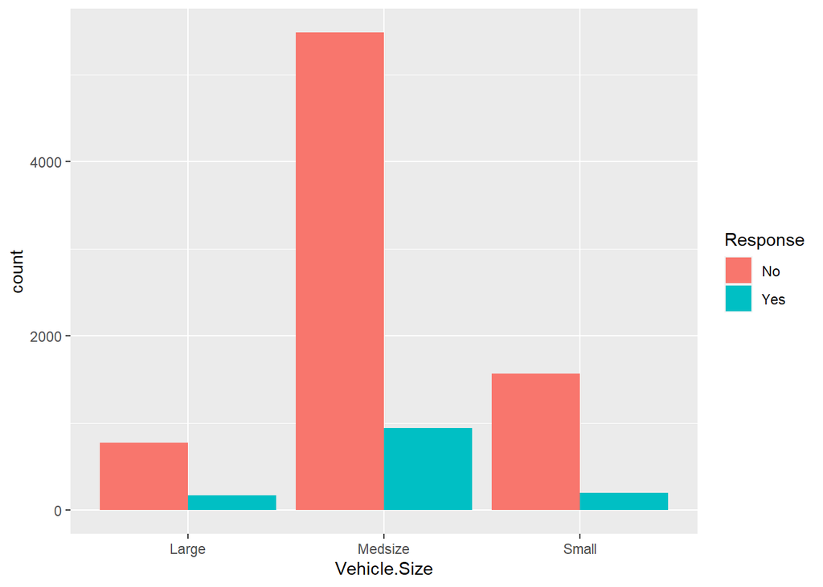

```r
ggplot(data1, aes(Vehicle.Size, fill= Response))+geom_bar(position='dodge')
```

#Mid-size vehicle owners are intrested in extending their insurance premium rather than small and large size vehicles.

#Splitting the dataset into train and test

```r
#dividing the data
library(caTools)
set.seed(100) #we use this for same sampling(random sampling)
split1=sample.split(data1$Response, SplitRatio = 0.70)
summary(split1) #false is test and true is train dataset
```

```
##    Mode   FALSE    TRUE
## logical    2740    6394
```

```r
datatest=subset(data1,split1==FALSE)  #false means it will create the test data
datatrain=subset(data1, split1== TRUE)  #true means it will create the train data
dim(datatest)  #dimensions of datatest
```

```
## [1] 2740   22
```

```r
dim(datatrain)  #dimensions of the datatrain
```

```
## [1] 6394   22
```

#Logistic Regression #Logistic regression is about having categorical dependent variable and independent variable consists of combination of both categorical and scale variable.

```r
library(caret)
library(Rcpp)
reg1<-train(Response~.,
            method ="glm",
            family = "binomial",
            data=datatrain)
```

[output not shown]

[output cut: 16 more lines]

[output not shown]

```r
summary(reg1)
```

```
##
## Call:
## NULL
##
## Deviance Residuals:
##      Min        1Q    Median        3Q       Max
## -2.38192  -0.55783  -0.36142  -0.00019   2.95684
##
## Coefficients: (2 not defined because of singularities)
##                                   Estimate Std. Error z value Pr(>|z|)
## (Intercept)                     -1.917e+00  5.437e-01  -3.525 0.000423 ***
## StateCalifornia                  2.740e-02  1.161e-01   0.236 0.813477
## StateNevada                      4.034e-02  1.598e-01   0.252 0.800659
## StateOregon                     -2.536e-03  1.207e-01  -0.021 0.983237
## StateWashington                 -6.620e-02  1.678e-01  -0.394 0.693229
## Customer.Lifetime.Value         -6.978e-06  6.556e-06  -1.064 0.287204
## CoverageExtended                -7.561e-02  1.525e-01  -0.496 0.620066
## CoveragePremium                  1.199e-02  3.160e-01   0.038 0.969726
## EducationCollege                 1.706e-01  1.058e-01   1.612 0.106860
## EducationDoctor                  5.839e-01  2.002e-01   2.917 0.003536 **
## `EducationHigh School or Below` -7.756e-02  1.094e-01  -0.709 0.478544
## EducationMaster                  5.976e-01  1.510e-01   3.956 7.61e-05 ***
## EmploymentStatusEmployed        -1.900e-01  1.907e-01  -0.996 0.319191
## `EmploymentStatusMedical Leave`  1.449e-01  2.288e-01   0.633 0.526523
## EmploymentStatusRetired          2.568e+00  2.507e-01  10.240  < 2e-16 ***
## EmploymentStatusUnemployed      -6.815e-01  1.997e-01  -3.412 0.000645 ***
## GenderM                         -1.224e-02  8.156e-02  -0.150 0.880714
## Income                           3.509e-06  2.308e-06   1.521 0.128330
## Location.CodeSuburban            1.360e+00  1.780e-01   7.639 2.19e-14 ***
## Location.CodeUrban               1.184e-01  1.728e-01   0.685 0.493463
## Marital.StatusMarried           -5.852e-01  1.068e-01  -5.481 4.24e-08 ***
## Marital.StatusSingle            -5.956e-01  1.273e-01  -4.678 2.90e-06 ***
## Monthly.Premium.Auto             8.828e-03  6.160e-03   1.433 0.151816
## Months.Since.Last.Claim         -3.427e-03  4.054e-03  -0.845 0.397955
## Months.Since.Policy.Inception   -1.675e-04  1.451e-03  -0.115 0.908094
## Number.of.Open.Complaints       -7.895e-03  4.615e-02  -0.171 0.864159
## Number.of.Policies              -2.130e-02  1.699e-02  -1.253 0.210027
## `Policy.TypePersonal Auto`      -1.103e-01  2.184e-01  -0.505 0.613640
## `Policy.TypeSpecial Auto`        6.019e-01  3.432e-01   1.754 0.079477 .
## `PolicyCorporate L2`             1.980e-01  2.589e-01   0.765 0.444429
```

[output cut: 16 more lines]

```
## `Vehicle.ClassSports Car`        3.252e-01  3.131e-01   1.039 0.299004
## Vehicle.ClassSUV                 1.731e-01  2.774e-01   0.624 0.532618
## `Vehicle.ClassTwo-Door Car`      1.120e-01  1.064e-01   1.053 0.292396
## Vehicle.SizeMedsize             -1.558e-01  1.267e-01  -1.230 0.218711
## Vehicle.SizeSmall               -6.465e-01  1.551e-01  -4.168 3.07e-05 ***
## ---
## Signif. codes:  0 '***' 0.001 '**' 0.01 '*' 0.05 '.' 0.1 ' ' 1
##
## (Dispersion parameter for binomial family taken to be 1)
##
##     Null deviance: 5253.8  on 6393  degrees of freedom
## Residual deviance: 4053.3  on 6345  degrees of freedom
## AIC: 4151.3
##
## Number of Fisher Scoring iterations: 17
```

#There are different variables in this regression model where dependent variable is response with yes and no. There are many independent variables consists of State, Customer Lifetime Value,Coverage, Education,EmploymentStatus, Gender, Income, Location Code, Marital Status, Monthly Premium Auto, Months Since Last Claim, Months Since Policy, Inception Number of Open Complaints, Number of Policies, Policy Type ,Policy ,Renew Offer Type, Sales Channel ,Total Claim Amount Vehicle Class, Vehicle Size.

# From the output we can see that there is a difference between Null deviance and Residual deviance indicating the model is good model

# Explanation of the parameters

#The significant independent variables from this regression are Education,EmploymentStatus, Location Code, Marital Status, Renew Offer Type, Sales Channel ,Total Claim Amount and vehicle size. #Deviance is a measure of goodness of fit of a model. Higher numbers always indicates bad fit. #The null deviance is 5253.8 it shows how well the response is predicted by the model with nothing but an intercept withrespect to the independent variables. #The residual deviance is 4053.3 it shows how well the response is predicted by the model when the predictors are included. # The Akaike information criterion (AIC) will explain the model complexity and preferably lower value will indicates a better fit model. So,4151.3 of AIC and is lower value indicating the model is good fit #As there are very little significant values, we need to run few other models to check whether it is good fit or not.

#Checking the final model of the logistic regression

```r
reg1$finalModel
```

```
##
## Call:  NULL
##
## Coefficients:
##                     (Intercept)                  StateCalifornia
##                      -1.917e+00                        2.740e-02
##                     StateNevada                      StateOregon
##                       4.034e-02                       -2.536e-03
##                 StateWashington          Customer.Lifetime.Value
##                      -6.620e-02                       -6.978e-06
##                CoverageExtended                  CoveragePremium
##                      -7.561e-02                        1.199e-02
##                EducationCollege                  EducationDoctor
##                       1.706e-01                        5.839e-01
## `EducationHigh School or Below`                  EducationMaster
##                      -7.756e-02                        5.976e-01
##        EmploymentStatusEmployed  `EmploymentStatusMedical Leave`
##                      -1.900e-01                        1.449e-01
##         EmploymentStatusRetired       EmploymentStatusUnemployed
##                       2.568e+00                       -6.815e-01
##                         GenderM                           Income
##                      -1.224e-02                        3.509e-06
##           Location.CodeSuburban               Location.CodeUrban
##                       1.360e+00                        1.184e-01
##           Marital.StatusMarried             Marital.StatusSingle
##                      -5.852e-01                       -5.956e-01
##            Monthly.Premium.Auto          Months.Since.Last.Claim
##                       8.828e-03                       -3.427e-03
##   Months.Since.Policy.Inception        Number.of.Open.Complaints
##                      -1.675e-04                       -7.895e-03
##              Number.of.Policies       `Policy.TypePersonal Auto`
##                      -2.130e-02                       -1.103e-01
##       `Policy.TypeSpecial Auto`             `PolicyCorporate L2`
##                       6.019e-01                        1.980e-01
##            `PolicyCorporate L3`              `PolicyPersonal L1`
##                      -5.447e-02                        2.430e-01
##             `PolicyPersonal L2`              `PolicyPersonal L3`
##                       1.951e-01                               NA
##              `PolicySpecial L1`               `PolicySpecial L2`
##                      -1.496e-02                       -4.758e-01
##              `PolicySpecial L3`           Renew.Offer.TypeOffer2
##                              NA                        7.321e-01
##          Renew.Offer.TypeOffer3           Renew.Offer.TypeOffer4
##                      -1.934e+00                       -1.677e+01
##             Sales.ChannelBranch       `Sales.ChannelCall Center`
##                      -6.029e-01                       -7.065e-01
##                Sales.ChannelWeb               Total.Claim.Amount
##                      -6.427e-01                       -1.387e-03
##       `Vehicle.ClassLuxury Car`        `Vehicle.ClassLuxury SUV`
##                      -1.099e+00                       -1.660e-01
##       `Vehicle.ClassSports Car`                 Vehicle.ClassSUV
##                       3.252e-01                        1.731e-01
##     `Vehicle.ClassTwo-Door Car`              Vehicle.SizeMedsize
##                       1.120e-01                       -1.558e-01
##               Vehicle.SizeSmall
##                      -6.465e-01
##
## Degrees of Freedom: 6393 Total (i.e. Null);  6345 Residual
## Null Deviance:       5254
## Residual Deviance: 4053  AIC: 4151
```

#The significant independent variables from this regression are Education,EmploymentStatus, Location Code, Marital Status, Renew Offer Type, Sales Channel ,Total Claim Amount and vehicle size. #Deviance is a measure of goodness of fit of a model. Higher numbers always indicates bad fit. #The null deviance is 5253.8 it shows how well the response is predicted by the model with nothing but an intercept withrespect to the independent variables. #The residual deviance is 4053.3 it shows how well the response is predicted by the model when the predictors are included. # The Akaike information criterion (AIC) will explain the model complexity and preferably lower value will indicates a better fit model. So,4151.3 of AIC and is lower value indicating the model is good fit

#we need to check whether the model is fit or not

```r
library(blorr)
library(Rcpp)


blr_model_fit_stats(reg1$finalModel)
```

```
##                               Model Fit Statistics
## ---------------------------------------------------------------------------------
## Log-Lik Intercept Only:     -2626.887    Log-Lik Full Model:            -2026.666
## Deviance(6343):              4053.331    LR(50):                         1200.443
##                                          Prob > LR:                         0.000
## MCFadden's R2                   0.228    McFadden's Adj R2:                 0.209
## ML (Cox-Snell) R2:              0.171    Cragg-Uhler(Nagelkerke) R2:        0.306
## McKelvey & Zavoina's R2:        0.901    Efron's R2:                        0.201
## Count R2:                       0.870    Adj Count R2:                      0.094
## BIC:                         4482.724    AIC:                            4151.331
## ---------------------------------------------------------------------------------
```

#From the previous test we can say that the model is good fit, but the r2 values here are very less, likely hood ratio is also good, so we can say that the model is good in terms of likelyhood ratio. #The different R2 values in the model fit statistics are low but we cannit decide on this model, so we need to do the hosmer lemeshow to know whether the model is good or not. #The Akaike information criterion (AIC) and Bayesian information criterion (BIC) will explain the model complexity and preferably lower value will indicates a better fit model. So, 4151.3 of AIC and 4482,724 of BIC are lower values indicating the model is good fit

#hosmer lemeshow #null hypothesis for hosmer lemeshow- model is good fit #alternate- not good fit model

```r
blr_test_hosmer_lemeshow(reg1$finalModel)
```

```
##            Partition for the Hosmer & Lemeshow Test
## --------------------------------------------------------------
##                         def = 1                 def = 0
## Group    Total    Observed    Expected    Observed    Expected
## --------------------------------------------------------------
##   1       640        0          0.00        640        640.00
##   2       639        4          5.64        635        633.36
##   3       639        18        19.34        621        619.66
##   4       640        21        38.13        619        601.87
##   5       639        34        56.46        605        582.54
##   6       639        77        74.73        562        564.27
##   7       640       125        95.66        515        544.34
##   8       639       172        126.19       467        512.81
##   9       639       166        168.92       473        470.08
##  10       640       299        330.93       341        309.07
## --------------------------------------------------------------
##
##      Goodness of Fit Test
## ------------------------------
## Chi-Square    DF    Pr > ChiSq
## ------------------------------
##  56.3905      8       0.0000
## ------------------------------
```

#The model says the pvalue is less than 0.05, we reject the null hypothesis and accept the alternate hypothesis. saying the model is not good fit, according to hosmer lemeshow

#confusion matrix

```r
blr_confusion_matrix(reg1$finalModel,cutoff = 0.5)
```

```
## Confusion Matrix and Statistics
##
##           Reference
## Prediction   No  Yes
##          0 5402  754
##          1   76  162
##
##
##                 Accuracy : 0.8702
##      No Information Rate : 0.8567
##
##                    Kappa : 0.2356
##
## McNemars's Test P-Value  : 0.0000
##
##              Sensitivity : 0.1769
##              Specificity : 0.9861
##           Pos Pred Value : 0.6807
##           Neg Pred Value : 0.8775
##               Prevalence : 0.1433
##           Detection Rate : 0.0253
##     Detection Prevalence : 0.0372
##        Balanced Accuracy : 0.5815
##                Precision : 0.6807
##                   Recall : 0.1769
##
##         'Positive' Class : 1
```

#The accuracy is 87percent , this says the model is right classication. #The kappa value is 0.23, sensitivity is 0.17, specificity is 0.98 and precision is 0.68

#Here we are determining the confusion matrix to know accuracy, specificity and sensitivity.

```r
predict1<-predict(reg1, datatest)
confusionMatrix(predict1, datatest$Response)
```

```
## Confusion Matrix and Statistics
##
##           Reference
## Prediction   No  Yes
##        No  2321  324
##        Yes   27   68
##
##                Accuracy : 0.8719
##                  95% CI : (0.8588, 0.8842)
##     No Information Rate : 0.8569
##     P-Value [Acc > NIR] : 0.01267
##
##                   Kappa : 0.2367
##
##  Mcnemar's Test P-Value : < 2e-16
##
##             Sensitivity : 0.9885
##             Specificity : 0.1735
##          Pos Pred Value : 0.8775
##          Neg Pred Value : 0.7158
##              Prevalence : 0.8569
##          Detection Rate : 0.8471
##    Detection Prevalence : 0.9653
##       Balanced Accuracy : 0.5810
##
##        'Positive' Class : No
##
```

#The confusion matrix says that right classification of model is 87% said by accuracy i.e., people who are predicted saying no and people who are actually said no are 2321 and eople who actually said yes and actual is also yes is 68.

#The people who said they are not intrested to take insurance and we predicted that they dont want any insurance is 2321 and the sensitivity is 98percent, which means we predited it right.

#The people who said they will extend their insuranc epolicy and we predicted that people will take the insurance policy are 68 but the specificity is low